# Building Permit data - EDA

Leonard Seok

last update: 16 May 2020

```r
# setwd("C:\\Users\\Leonard\\Desktop\\Datascience for R\\Projects\\EDA_1")
library(tidyverse); library(gridExtra); library(ggplot2); library(reshape); library(caret)
```

## About the data

Source : https://www.recenter.tamu.edu/data/building-permits/

This site contains Building permit data for single-family, 2-4 family and 5-plus family units for states, metropolitan statistical areas (MSAs) and Texas counties.

Building permits are granted by the US government (or some other regulatory body) before the construction of a new or existing building can legally occur. Building permits data and its underlying trends are important to economists and investors since it acts as a signal to the state of economy. It is associated with many key indicators of economic activity, such as housing demand and employment.

This objective of this project is to Explore and visualise the data, while trying to form meaningful observations through some rather basic seasonality modelling in an attempt to detrend the data.

## Import the data

We start off by reading in the data, and checking out its structure.

```r
perm <- read.csv("dataPermit_full.csv")
str(perm)
```

```
## 'data.frame':    99880 obs. of  14 variables:
##  $ area        : Factor w/ 381 levels "Abilene, TX",..: 1 1 1 1 1 1 1 1 1 1 ...
##  $ date        : Factor w/ 411 levels "01/1980","01/1981",..: 1 36 71 106 140 174 208 242 276 310 ...
##  $ f1units     : int  24 39 38 29 29 42 48 67 53 80 ...
##  $ f1change    : Factor w/ 3027 levels "-0.1","-0.2",..: 3027 3027 3027 3027 3027 3027 3027 3027 3027 3027 ...
##  $ f1value     : int  67900 75900 78000 66500 77600 66500 67600 69000 60800 73000 ...
##  $ f1valchange : Factor w/ 2690 levels "-0.1","-0.2",..: 2690 2690 2690 2690 2690 2690 2690 2690 2690 2690 ...
##  $ f24units    : int  4 0 4 0 0 0 18 0 2 2 ...
##  $ f24change   : Factor w/ 2482 levels "-0.2","-0.3",..: 2482 2482 2482 2482 2482 2482 2482 2482 2482 2482 ...
##  $ f24value    : int  46200 0 37000 0 0 0 24400 0 31200 23800 ...
##  $ f24valchange: Factor w/ 3069 levels "-0.1","-0.2",..: 3069 3069 3069 3069 3069 3069 3069 3069 3069 3069 ...
##  $ f5units     : int  200 0 0 0 0 0 0 0 0 152 ...
##  $ f5change    : Factor w/ 5196 levels "-0.2","-0.3",..: 5196 5196 5196 5196 5196 5196 5196 5196 5196 5196 ...
##  $ f5value     : int  12800 0 0 0 0 0 0 0 0 22700 ...
##  $ f5valchange : Factor w/ 3273 levels "-0.1","-0.2",..: 3273 3273 3273 3273 3273 3273 3273 3273 3273 3273 ...
```

```r
head(perm)
```

```
##          area    date f1units f1change f1value f1valchange f24units
## 1 Abilene, TX 01/1980      24     null   67900        null        4
## 2 Abilene, TX 02/1980      39     null   75900        null        0
## 3 Abilene, TX 03/1980      38     null   78000        null        4
## 4 Abilene, TX 04/1980      29     null   66500        null        0
## 5 Abilene, TX 05/1980      29     null   77600        null        0
## 6 Abilene, TX 06/1980      42     null   66500        null        0
##   f24change f24value f24valchange f5units f5change f5value f5valchange
## 1      null    46200         null     200     null   12800        null
## 2      null        0         null       0     null       0        null
## 3      null    37000         null       0     null       0        null
## 4      null        0         null       0     null       0        null
## 5      null        0         null       0     null       0        null
## 6      null        0         null       0     null       0        null
```

We can see that NAs are read in as nulls (Character, not proper NAs) We can also see that some fields are read in as factors where they really should be numerics (due to the “null” being NAs)

```r
anyNA(perm) # This checks to confirm that there are no NAs, only nulls
```

```
## [1] FALSE
```

```r
summary(perm$f1change)
```

```
##       0    null    -100     -50     100   -33.3      50     -25    33.3
##    5687    4574    1228    1173    1098     874     831     708     629
##      25   -66.7     -20      20   -16.7     -40     200    66.7    16.7
##     518     500     481     423     394     389     389     367     355
##   -14.3   -28.6   -12.5    14.3      40   -11.1     -60    12.5     150
##     344     324     299     299     299     275     271     270     266
##   -42.9    11.1     -75   -37.5      75    -9.1     -10    28.6      10
##     253     245     244     238     231     226     224     223     222
##      60   -22.2    -8.3     300   -18.2    -7.7     9.1    42.9    18.2
##     213     207     207     204     202     192     192     191     183
##   -44.4    22.2     8.3      30   -15.4     -30    -7.1   -27.3   -13.3
##     180     178     178     177     176     175     175     172     170
##    37.5   -23.1    15.4    -6.7     7.1     7.7     6.7   -18.8   -55.6
##     169     164     162     161     159     158     157     156     156
##   -57.1    27.3    -6.2    18.8     5.6     6.2      80   -36.4    23.1
##     154     153     151     151     150     149     148     147     146
##     -80     5.3    13.3    -5.6    -5.9   -31.2   133.3   -11.8   -21.4
##     144     144     141     140     140     139     138     134     134
##   -21.1    -4.5    44.4      -5    11.8     5.9   -38.5    21.4   -26.7
##     132     132     132     131     131     129     128     128     127
##    -5.3   -13.6   -41.7   -27.8   -17.6   -30.8   -45.5   -35.7   -15.8
##     127     126     126     124     123     123     122     121     120
## (Other)
##   64810
```

```r
str(perm)
```

```
## 'data.frame':    99880 obs. of  14 variables:
##  $ area        : Factor w/ 381 levels "Abilene, TX",..: 1 1 1 1 1 1 1 1 1 1 ...
##  $ date        : Factor w/ 411 levels "01/1980","01/1981",..: 1 36 71 106 140 174 208 242 276 310 ...
##  $ f1units     : int  24 39 38 29 29 42 48 67 53 80 ...
##  $ f1change    : Factor w/ 3027 levels "-0.1","-0.2",..: 3027 3027 3027 3027 3027 3027 3027 3027 3027 3027 ...
##  $ f1value     : int  67900 75900 78000 66500 77600 66500 67600 69000 60800 73000 ...
##  $ f1valchange : Factor w/ 2690 levels "-0.1","-0.2",..: 2690 2690 2690 2690 2690 2690 2690 2690 2690 2690 ...
##  $ f24units    : int  4 0 4 0 0 0 18 0 2 2 ...
##  $ f24change   : Factor w/ 2482 levels "-0.2","-0.3",..: 2482 2482 2482 2482 2482 2482 2482 2482 2482 2482 ...
##  $ f24value    : int  46200 0 37000 0 0 0 24400 0 31200 23800 ...
##  $ f24valchange: Factor w/ 3069 levels "-0.1","-0.2",..: 3069 3069 3069 3069 3069 3069 3069 3069 3069 3069 ...
##  $ f5units     : int  200 0 0 0 0 0 0 0 0 152 ...
##  $ f5change    : Factor w/ 5196 levels "-0.2","-0.3",..: 5196 5196 5196 5196 5196 5196 5196 5196 5196 5196 ...
##  $ f5value     : int  12800 0 0 0 0 0 0 0 0 22700 ...
##  $ f5valchange : Factor w/ 3273 levels "-0.1","-0.2",..: 3273 3273 3273 3273 3273 3273 3273 3273 3273 3273 ...
```

Now lets fix the problematic nulls issue with an additional paramater na = “null”

```r
perm <- read.csv("dataPermit_full.csv", na = "null")
str(perm)
```

```
## 'data.frame':    99880 obs. of  14 variables:
##  $ area        : Factor w/ 381 levels "Abilene, TX",..: 1 1 1 1 1 1 1 1 1 1 ...
##  $ date        : Factor w/ 411 levels "01/1980","01/1981",..: 1 36 71 106 140 174 208 242 276 310 ...
##  $ f1units     : int  24 39 38 29 29 42 48 67 53 80 ...
##  $ f1change    : num  NA NA NA NA NA NA NA NA NA NA ...
##  $ f1value     : int  67900 75900 78000 66500 77600 66500 67600 69000 60800 73000 ...
##  $ f1valchange : num  NA NA NA NA NA NA NA NA NA NA ...
##  $ f24units    : int  4 0 4 0 0 0 18 0 2 2 ...
##  $ f24change   : num  NA NA NA NA NA NA NA NA NA NA ...
##  $ f24value    : int  46200 0 37000 0 0 0 24400 0 31200 23800 ...
##  $ f24valchange: num  NA NA NA NA NA NA NA NA NA NA ...
##  $ f5units     : int  200 0 0 0 0 0 0 0 0 152 ...
##  $ f5change    : num  NA NA NA NA NA NA NA NA NA NA ...
##  $ f5value     : int  12800 0 0 0 0 0 0 0 0 22700 ...
##  $ f5valchange : num  NA NA NA NA NA NA NA NA NA NA ...
```

Lets now define the variables we are dealing with :

- Area = Metropolitan Standard Area ( in the US )
- Date = Month/Year (Factor)
- f1 = Single Family House
- f24 = 2 - 4 Families House
- f5 = 5+ Families House
- units = Count of buildings
- value = Average Building value

Lets Check how far back this data goes.

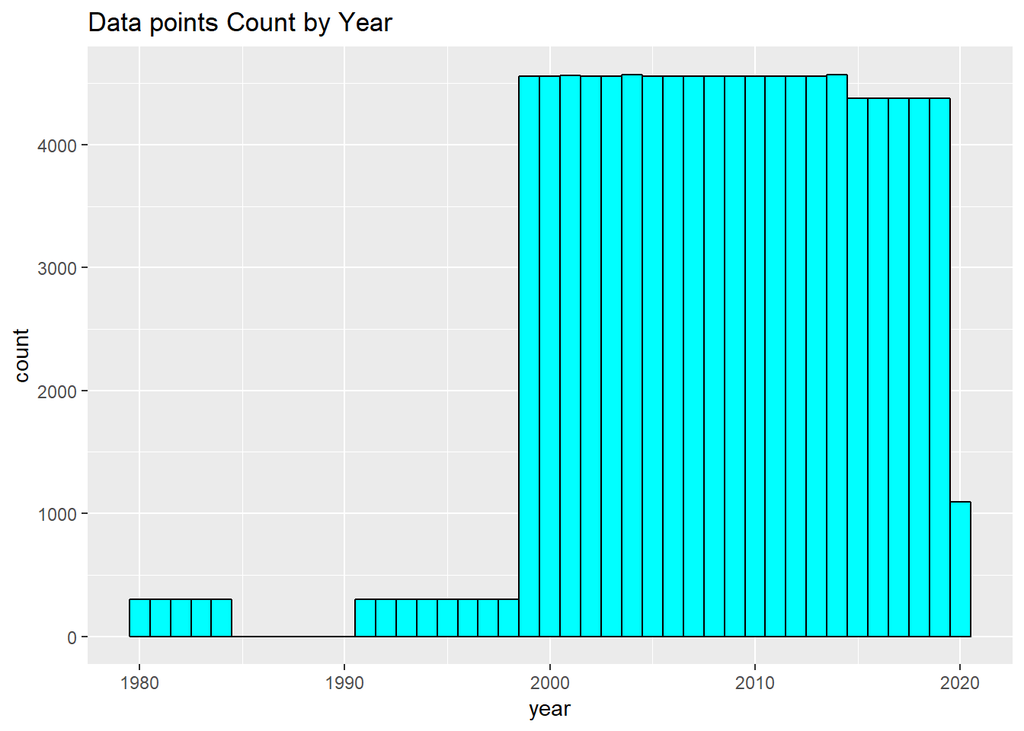

```r
perm.1 <- perm %>%
  mutate(year = as.numeric(str_sub(date,-4,-1))
         , month = as.numeric(str_sub(date,1,2))
         , yyyymm = year * 100 + month
         , yyyymm_G = year + (month-1)/12
         )

(year.dist <- ggplot(perm.1, aes(year)) +
  geom_histogram(binwidth = 1, color = 'black', fill = 'cyan') +
    ggtitle("Data points Count by Year")
)
```

```r
perm.2 <- perm.1 %>%
  filter(year >= 2000)
```

## General EDA

Look at Counts by Year

```r
perm.2 %>% count(year) %>% arrange(desc(year))
```

```
## # A tibble: 21 x 2
##     year     n
##    <dbl> <int>
##  1  2020  1095
##  2  2019  4380
##  3  2018  4380
##  4  2017  4380
##  5  2016  4380
##  6  2015  4380
##  7  2014  4572
##  8  2013  4560
##  9  2012  4560
## 10  2011  4560
## # ... with 11 more rows
```

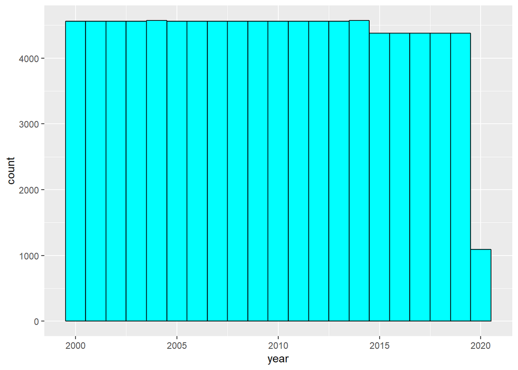

```r
ggplot(perm.2, aes(year)) +
  geom_histogram(binwidth = 1, color='black', fill='cyan')
```

Look at Counts by Area

```r
perm.2 %>% count(area)
```

```
## # A tibble: 381 x 2
##    area                                  n
##    <fct>                             <int>
##  1 Abilene, TX                         243
##  2 Akron, OH                           243
##  3 Albany-Schenectady-Troy, NY         243
##  4 Albany, GA                          243
##  5 Albany, OR                          243
##  6 Albuquerque, NM                     243
##  7 Alexandria, LA                      243
##  8 Allentown-Bethlehem-Easton, PA-NJ   243
##  9 Altoona, PA                         243
## 10 Amarillo, TX                        243
## # ... with 371 more rows
```

Alot of areas seem to have the same counts, lets check with a double count ( to count the number of area counts )

```r
perm.2 %>% count(area) %>% count(n)
```

```
## # A tibble: 4 x 2
##       n    nn
##   <int> <int>
## 1   135     1
## 2   180    16
## 3   196     1
## 4   243   363
```

We can see that most areas (363 of them) have 243 records.

Now lets look at yearly figures across the different building profiles

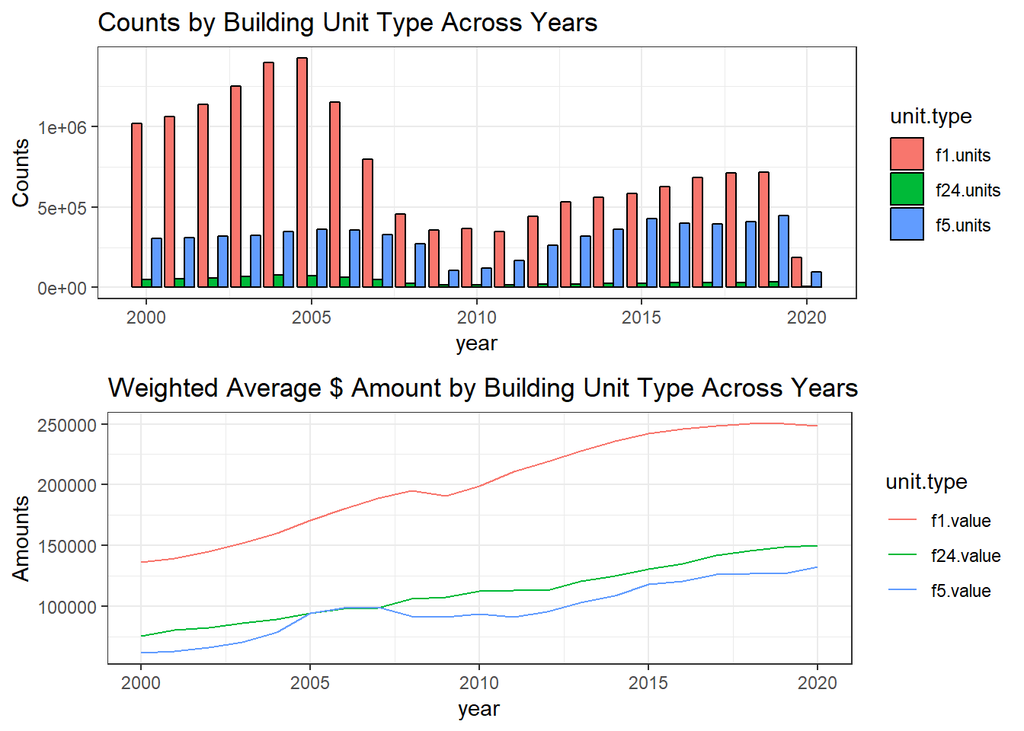

```r
counts.by.year <- perm.2 %>% group_by(year) %>%
  summarise(f1.units = sum(f1units)
            , f24.units = sum(f24units)
            , f5.units = sum(f5units)) %>%
  gather(key = "unit.type", value = "Counts", -year) %>%
  ggplot(aes(x=year, y=Counts, fill = unit.type)) +
  geom_bar(aes(group = unit.type), color = 'black', stat = "Identity", position = "dodge") +
  theme_bw() +
  ggtitle("Counts by Building Unit Type Across Years")

Amounts.by.year <- perm.2 %>%
  group_by(year) %>%
  summarise(f1.value = sum(as.numeric(f1value)*as.numeric(f1units))/sum(as.numeric(f1units)) # as.numerics is required as INT types can overflow if too large
            , f24.value = sum(as.numeric(f24value)*as.numeric(f24units))/sum(as.numeric(f24units))
            , f5.value = sum(as.numeric(f5value)*as.numeric(f5units))/sum(as.numeric(f5units)) ) %>%
  gather(key = "unit.type", value = "Amounts", -year) %>%
  ggplot(aes(x=year, y=Amounts, color = unit.type)) +
  geom_line(aes(group = unit.type)) +
  theme_bw() +
  ggtitle("Weighted Average $ Amount by Building Unit Type Across Years")

grid.arrange(counts.by.year, Amounts.by.year, nrow =2)
```

We can see from here that:

- Single family units has the highest volumes across the years, followed by 5+ units, then 2-4 units.
- From 2007-2010 we can see a clear dip across all units in terms of volumes, likely due to the decrease in permit demand caused by the GFC.
- Post 2010, we can see overall increases in permits - particularly for single family units. This means that general economic activity is picking up again and that more US citizens have accumulated enough finances to afford their homes.
- Single family unit buildings have the highest weighted average value. This makes sense since units with more family units generally singal citizens who are of a lower socio-economic class and cannot afford a residence for their own family.
- We can see slight dips in the average building values for single and 5+ units during the GFC period. Interestingly, the averages for 2-4 units was not affected.

## Single Family Building Units

Plot the number of single family units over time overall. We can see a noticable decrease starting 2007 to 2010, which is when the GFC happened. This clearly signalled the significant slow down of economic activity in the housing market due to the crisis.

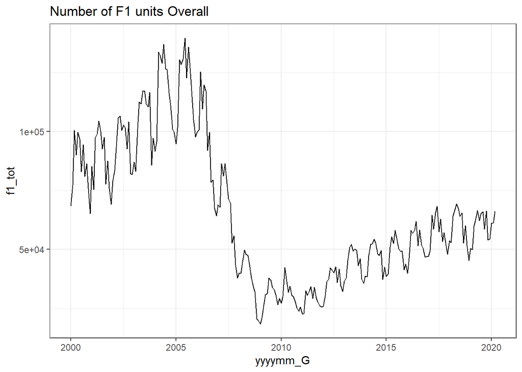

```r
perm.2 %>% group_by(yyyymm_G) %>%
  summarise(f1_tot = sum(f1units)) %>%
  ggplot(aes(x=yyyymm_G,y=f1_tot)) +
  geom_line() +
  ggtitle("Number of F1 units Overall") + theme_bw()
```

Plot the number of single family units over time, this time by Area.

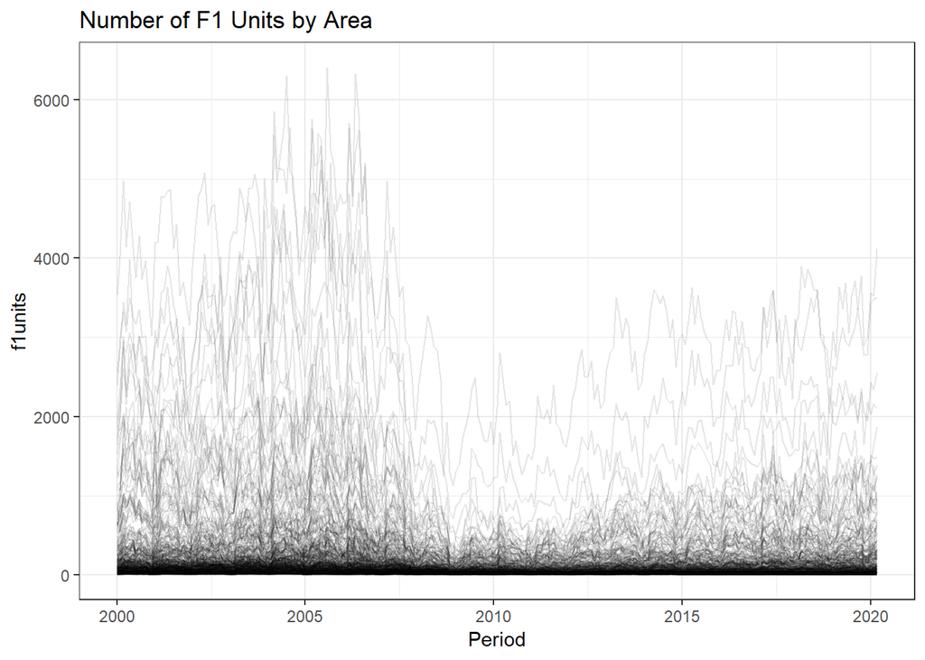

```r
ggplot(perm.2, aes(x=yyyymm_G, y=f1units)) +
  geom_line(aes(group=area), alpha = 1/10) +
  ggtitle("Number of F1 Units by Area") +
  xlab("Period") +
  theme_bw()
```

This looks bit messy due to the large amounts of distinct areas. Lets focus on a subset of areas with larger volumes of data. We do this by taking the areas that are in the top 25% in terms of volumes.

```r
# Lets take the top 25% areas by average monthly units
length(unique(perm.2$area)) # we have 381 cities in total
```

```
## [1] 381
```

```r
top.25 <- round(length(unique(perm.2$area)) * 0.25)

(f1.by.area <- perm.2 %>%
  group_by(area) %>%
  summarise(average.unit.count = mean(f1units)) %>%
  arrange(desc(average.unit.count)) %>%
  head(top.25)
)
```

```
## # A tibble: 95 x 2
##    area                                         average.unit.count
##    <fct>                                                     <dbl>
##  1 Houston-The Woodlands-Sugar Land, TX                      2973.
##  2 Dallas-Fort Worth-Arlington, TX                           2543.
##  3 Atlanta-Sandy Springs-Roswell, GA                         2500.
##  4 Phoenix-Mesa-Scottsdale, AZ                               2112.
##  5 Washington-Arlington-Alexandria, DC-VA-MD-WV              1425.
##  6 Riverside-San Bernardino-Ontario, CA                      1374.
##  7 Chicago-Naperville-Elgin, IL-IN-WI                        1369.
##  8 Charlotte-Concord-Gastonia, NC-SC                         1194.
##  9 New York-Newark-Jersey City, NY-NJ-PA                     1181.
## 10 Orlando-Kissimmee-Sanford, FL                             1160.
## # ... with 85 more rows
```

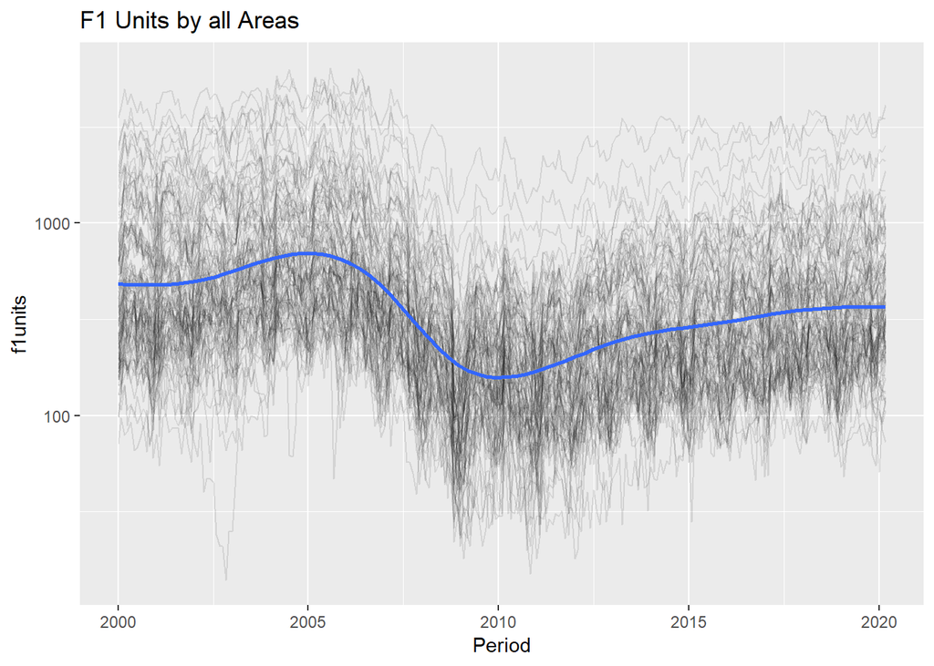

```r
perm.large <- perm.2 %>% filter(area %in% f1.by.area$area)

ggplot(perm.large, aes(x=yyyymm_G, y=f1units)) + geom_line(aes(group = area), alpha = 1/10) +
  scale_y_log10() + # a log transform can help when there is large scale discrepancies within the data
  geom_smooth() +
  ggtitle("F1 Units by all Areas") +
  xlab("Period")
```

With the Log scale to normalise the data, we can roughly see some seasonal patterns within a year here. We can also see a long term increasing trend in single unit permits post the GFC period.

## Model to partition the seasonality pattern within a year

We will now build a simple model to partition the seasonality within a year, and detrend the data. Lets pick an area to build the model on - say we pick the one with largest average unit counts which is Houston.

```r
(area.name <- f1.by.area %>% filter(average.unit.count == max(average.unit.count)) %>% select(area))
```

```
## # A tibble: 1 x 1
##   area
##   <fct>
## 1 Houston-The Woodlands-Sugar Land, TX
```

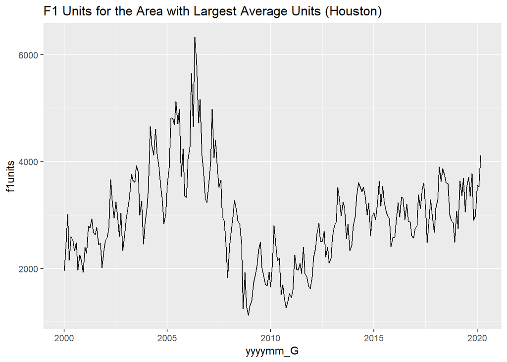

```r
area.1 <- perm.2 %>% filter(area == area.name$area)

ggplot(area.1, aes(x=yyyymm_G, y = f1units)) + geom_line() + ggtitle("F1 Units for the Area with Largest Average Units (Houston)")
```

```
## geom_path: Each group consists of only one observation. Do you need to
## adjust the group aesthetic?
## geom_path: Each group consists of only one observation. Do you need to
## adjust the group aesthetic?
```

[figure not shown]

```r
# Highlight the 2019 and 2020 years in red (the later years)
ggplot(area.1, aes(x=factor(month), y = f1units)) + geom_line(aes(group = year, color = year)) + scale_color_gradient(low = "#56B1F7", high = "#132B43") +
  geom_line(data = area.1 %>% filter(year == 2020), color = 'red') +
  geom_line(data = area.1 %>% filter(year == 2019), color = 'red', linetype = 'longdash') +
  scale_y_log10() +
  ggtitle("Seasonality within a year (F1 in Houstons)") +
  xlab("Month") +
  theme_bw()
```

We can see some trends here - some points to note:

- Building permits activities start falling in Aug/Sep, and hits lowest in December. This could be due to the colder weather in these periods that cause lower demands/housing market activities in general?
- Permit activities peak around May/June - which is when its getting warm/hot - perhaps this is when people are inherently more active overall?
- Is this trend the same for all areas other than Houston?
- Is this trend same across all building unit types?

## Seasonality model for Houston (for years 2010 onwards)

Lets build a simple linear model to quantify this seasonality signal just for Houston. Lets work on data 2010 onwards, since including GFC periods could cause noise in our predictions.

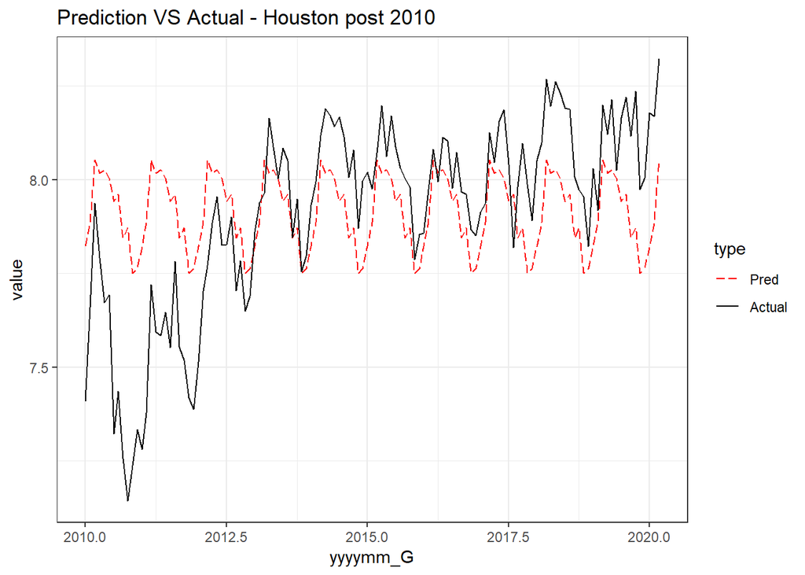

```r
area.2 <- area.1 %>% filter(year>=2010)

set.seed(13)
sig.mod.hous <- train(log(f1units) ~ factor(month), data = area.2, method = "lm")

area.2$f1unit.pred <- predict(sig.mod.hous, newdata = area.2)

area.2 %>% mutate(log.f1units = log(f1units)) %>%
  select(yyyymm_G, log.f1units, f1unit.pred) %>%
  gather(key = 'type', value = 'value', -yyyymm_G) %>%
  ggplot(aes(x=yyyymm_G, y=value, color = type, linetype = type)) +
  geom_line(aes(group = type)) +
  scale_linetype_manual(labels = c("Pred", "Actual") ,values=c("longdash","solid")) +
  scale_color_manual(labels = c("Pred", "Actual") ,values = c("red", "black")) +
  ggtitle('Prediction VS Actual - Houston post 2010') + theme_bw()
```

Lets have a look at the residual plot. We would like to know what is the underlying trend of we were to ignore the monthly pattern (basically the remaining signal that is not captured by the seasonality model.)

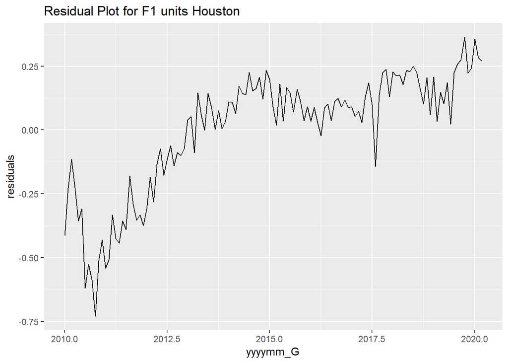

```r
area.2 %>% mutate(log.f1units = log(f1units)) %>%
  select(yyyymm_G, log.f1units, f1unit.pred) %>%
  mutate(residuals = log.f1units - f1unit.pred) %>%
  ggplot(aes(x=yyyymm_G, y=residuals)) +
  geom_line() +
  ggtitle('Residual Plot for F1 units Houston')
```

Stripping out the seasonality pattern, we can see the longer term trend more clearly.

## Seasonality Model for all large areas (for years 2010 onwards)

We will now apply this linear model to all the top 25% largest areas. We will do this efficiently by nesting our data into different areas, and applying the model using maps.

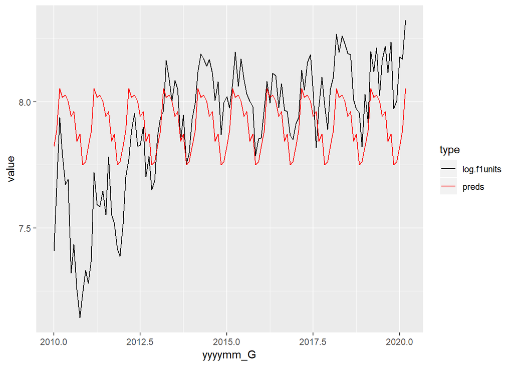

```r
# We split the dataset into individual datasets by area
nested.area <- perm.large %>% filter(year >= 2010) %>% group_by(area) %>% nest()

# Create a function for the model, this is so we can apply it to the nested datasets for each area
area.model <- function(df, res, pred){
  f <- as.formula(paste(res, paste(pred, collapse = '+'), sep = '~'))
  return(lm(f, data = df))
}

# For example , we run the model on just the Houston Area
model.Hous <- area.model(area.2, res="log(f1units+1)", pred="factor(month)")

# Now lets apply it to the whole nested sets using map - we can see more examples of nested models here https://drsimonj.svbtle.com/running-a-model-on-separate-groups
area.model.all <- nested.area %>%
  mutate(
          # First step is to map the model to each nested set
          model = map(.x=data, .f=~area.model(df=.x,res="log(f1units+1)", pred="factor(month)"))
          # then we can manually obtain the predicted and the residuals
         , preds = map2(.x=model, .y=data, .f=~predict(.x, .y))
         , resi = map2(.x=data, .y=preds, .f=~log(.x$f1units) - .y)
         # another way of getting the predicted and residuals using what is stored in the model class
         , preds.check = map(.x=model, .f="fitted.values")
         , resi.check = map(.x=model, .f="residuals")
        )

perm.large.res <- area.model.all %>% unnest(data, preds,resi, preds.check, resi.check)

# lets check the plots for Houston with the individual Houston model what we have above
perm.large.res %>% filter(grepl("Houston",area)) %>%
  mutate(log.f1units = log(f1units)) %>%
  select(yyyymm_G, log.f1units, preds) %>%
  gather(key='type', value='value', -yyyymm_G) %>%
  ggplot(aes(x=yyyymm_G, y=value, color=type)) +
  geom_line() +
  scale_color_manual(values = c("black", "red"))
```

```r
# This checks out to be the same as the above chart
```

Now lets plot the residuals for all the top 25% largest areas. By detrending the data, we can observe the long term trend for the top 25% largest areas for Single Family units.

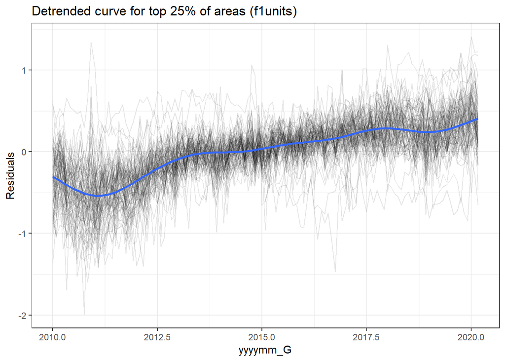

```r
perm.large.res %>% ggplot(aes(x=yyyymm_G, y=resi)) +
  geom_line(aes(group=area), alpha=1/10) +
  geom_smooth(se=F) +
  ggtitle("Detrended curve for top 25% of areas (f1units)") +
  ylab("Residuals") +theme_bw()
```

We will stop this EDA here for now. This project has significantly helped me with appreciating the basics in interrogating data using key R techniques - I hope this simple framework has benefited you too!